# Bayesian stan exercises

2023-05-02

## Fitting a univariate model in Stan

The `atsar` package contains a bunch of bundled Stan files for fitting univariate state space models in Stan, for those who want to try those methods. There’s also a bunch of options that we didn’t talk about in class, but can explore those in more detail here.

As a first example, we’ll use the MARSS gray whale dataset.

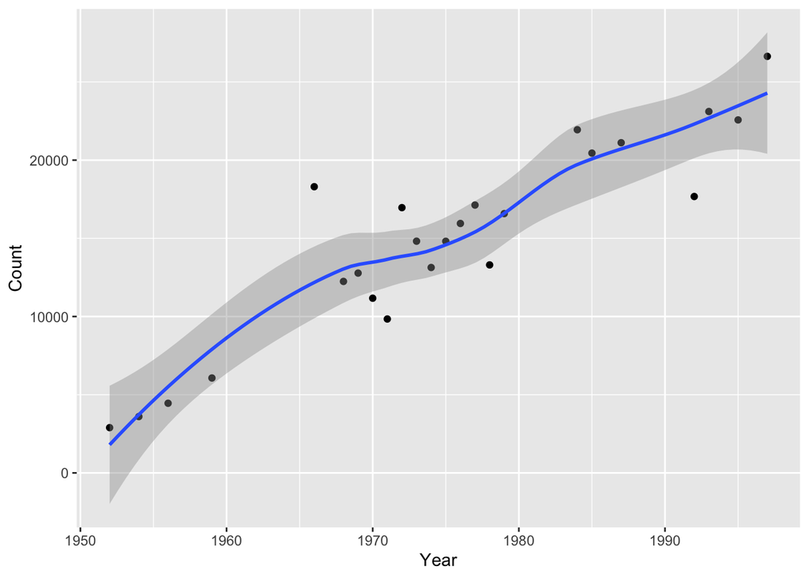

```r
library(ggplot2)
library(shinystan)
library(rstan)
library(broom.mixed)
library(bayesplot)
whale <- as.data.frame(MARSS::graywhales)

ggplot(whale, aes(Year,Count)) +
  geom_point() + geom_smooth()
```

An interesting question might be whether we can fit a Gompertz a population model and estimate the long term trend. To do this, we’ll use the `atsar` package.

```r
remotes::install_github("atsa-es/atsar")
```

It might be helpful to look at the documentation to see what kind of univariate models are available,

```r
?atsar::fit_stan
```

For the whale example, let’s start with the `ss_rw` model, a state space univariate model. We will fit the model in log-space and estimate drift.

```r
library(atsar)
```

We will start with a few hundred samples (normally you want the burn in period to be 1000-2000)

```r
set.seed(123)
fit <- fit_stan(y = log(whale$Count),
                model_name = "ss_rw",
                est_drift = TRUE,
                list(n_mcmc = 500,
                     n_burn = 100,
                     n_chain = 3))
```

Now let’s look at the R-hat values. Generally we want these to be < 1.1. Does it look like the model converges ok?

```r
fit
```

```
## Inference for Stan model: ss_rw.
## 3 chains, each with iter=1000; warmup=500; thin=1;
## post-warmup draws per chain=500, total post-warmup draws=1500.
##
##                mean se_mean   sd 2.5%   25%   50%   75% 97.5% n_eff Rhat
## sigma_process  0.14    0.00 0.04 0.06  0.11  0.14  0.16  0.23   149 1.01
## pred[1]        8.02    0.01 0.13 7.76  7.93  8.01  8.09  8.31   632 1.00
## pred[2]        8.11    0.01 0.14 7.84  8.01  8.12  8.20  8.40   792 1.00
## pred[3]        8.21    0.00 0.10 8.02  8.14  8.21  8.28  8.42  1363 1.00
## pred[4]        8.31    0.00 0.13 8.05  8.23  8.31  8.39  8.56  1081 1.00
## pred[5]        8.41    0.00 0.10 8.21  8.35  8.41  8.47  8.60  1759 1.00
## pred[6]        8.53    0.00 0.14 8.24  8.45  8.53  8.62  8.82  1038 1.00
## pred[7]        8.63    0.00 0.14 8.34  8.54  8.64  8.71  8.94  1195 1.00
## pred[8]        8.73    0.00 0.11 8.52  8.66  8.73  8.80  8.95  2089 1.00
## pred[9]        8.86    0.01 0.16 8.54  8.75  8.85  8.96  9.19   969 1.00
## pred[10]       8.99    0.01 0.19 8.62  8.86  8.98  9.11  9.38   964 1.00
## pred[11]       9.11    0.01 0.21 8.74  8.98  9.11  9.24  9.52   957 1.01
## pred[12]       9.24    0.01 0.21 8.84  9.09  9.24  9.37  9.65   867 1.01
## pred[13]       9.36    0.01 0.20 8.99  9.23  9.35  9.49  9.78   585 1.01
## pred[14]       9.49    0.01 0.19 9.14  9.36  9.48  9.62  9.87   433 1.01
## pred[15]       9.62    0.01 0.16 9.27  9.52  9.64  9.73  9.87   174 1.01
## pred[16]       9.54    0.01 0.14 9.25  9.44  9.54  9.63  9.80   367 1.00
## pred[17]       9.45    0.00 0.09 9.27  9.39  9.45  9.51  9.64  1342 1.00
## pred[18]       9.43    0.00 0.09 9.26  9.37  9.44  9.49  9.60  1241 1.00
## pred[19]       9.37    0.00 0.09 9.21  9.31  9.37  9.43  9.56   728 1.00
## pred[20]       9.36    0.01 0.10 9.17  9.29  9.36  9.44  9.57   285 1.01
## pred[21]       9.58    0.01 0.10 9.37  9.52  9.58  9.65  9.77   370 1.00
## pred[22]       9.58    0.00 0.09 9.40  9.52  9.58  9.63  9.75  1203 1.00
## pred[23]       9.54    0.00 0.09 9.37  9.49  9.55  9.60  9.72  1374 1.00
## pred[24]       9.60    0.00 0.08 9.44  9.55  9.60  9.65  9.77  2034 1.00
## pred[25]       9.65    0.00 0.09 9.48  9.60  9.65  9.71  9.81  1988 1.00
## pred[26]       9.68    0.00 0.09 9.50  9.63  9.68  9.73  9.85  1232 1.00
## pred[27]       9.61    0.00 0.09 9.44  9.54  9.61  9.67  9.81   580 1.00
## pred[28]       9.70    0.00 0.09 9.51  9.64  9.70  9.76  9.88  1734 1.00
## pred[29]       9.75    0.00 0.15 9.45  9.66  9.75  9.84 10.05  1021 1.00
## pred[30]       9.79    0.00 0.17 9.45  9.68  9.79  9.90 10.14  1323 1.00
## pred[31]       9.84    0.01 0.18 9.48  9.72  9.85  9.96 10.19  1055 1.00
## pred[32]       9.89    0.00 0.15 9.62  9.79  9.89  9.99 10.21  1052 1.00
## pred[33]       9.94    0.00 0.10 9.73  9.88  9.95 10.01 10.13  1189 1.00
## pred[34]       9.93    0.00 0.09 9.75  9.87  9.93  9.98 10.10  1874 1.00
## pred[35]       9.93    0.00 0.09 9.76  9.88  9.93  9.98 10.10  1671 1.00
## pred[36]       9.89    0.00 0.09 9.71  9.83  9.89  9.95 10.09   803 1.00
## pred[37]      10.01    0.00 0.09 9.82  9.96 10.01 10.06 10.19  1523 1.00
## pred[38]      10.06    0.00 0.09 9.88 10.01 10.06 10.11 10.23  1247 1.00
## pred[39]      10.16    0.00 0.10 9.94 10.09 10.16 10.22 10.36  1455 1.00
## sigma_obs      0.13    0.00 0.04 0.06  0.10  0.12  0.15  0.22   121 1.01
## mu[1]          0.06    0.00 0.02 0.01  0.04  0.06  0.07  0.11   388 1.01
## lp__          16.07    0.86 8.24 1.07 10.19 15.85 21.54 32.93    91 1.02
##
## Samples were drawn using NUTS(diag_e) at Tue May  2 14:43:06 2023.
## For each parameter, n_eff is a crude measure of effective sample size,
## and Rhat is the potential scale reduction factor on split chains (at
## convergence, Rhat=1).
```

It might be good to look at the posterior plots with ShinyStan. Specifically, let’s look at the posterior distributions and trace plots of the two variance parameters. Ask:

- are posterior distributions multi-modal?
- do MCMC trace plots look stationary?

```r
library(shinystan)
shinystan::launch_shinystan(fit)
```

```
##
## Launching ShinyStan interface... for large models this  may take some time.
```

```
##
## Listening on http://127.0.0.1:6809
```

Let’s try to look at the posterior of the trend – is it generally overlapping 0? Do you think the drift term should be kept in the model or not?

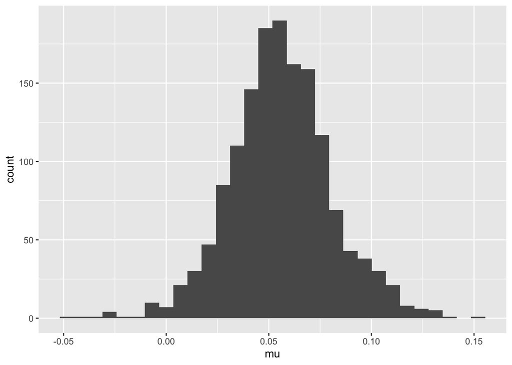

```r
pars <- as.data.frame(rstan::extract(fit))

ggplot(pars, aes(mu)) +
  geom_histogram()
```

### Can we estimate density dependence?

Density dependence is commonly interpreted as the autoregression term,

$$x_t = \phi*x_{t-1}+\mu+d_t; d_t \sim N(0,\sigma)$$

We can estimate the autoregression term by changing our model to `ss_ar` ,

```r
set.seed(123)
```

```r
fit2 <- fit_stan(y = log(whale$Count),
                model_name = "ss_ar",
                est_drift = TRUE,
                list(n_mcmc = 500,
                     n_burn = 100,
                     n_chain = 3))
```

Questions:

- Did this model appear to converge? Why or why not?
- Does the `phi` parameter appear well estimated?
- Extract the states, and plot them with the original data. For bonus points, include 95% Credible intervals

### Changing the family

In the above model(s) and all of MARSS, we have been modeling log-transformed data. Instead, the Stan code allows us to easily change the family. Given that the original whale dataset consists of counts, let’s try to change the family

- ```r
  set.seed(123)
  fit3 <- fit_stan(y = log(whale$Count),
                  model_name = "ss_rw",
                  est_drift = TRUE,
                  list(n_mcmc = 500,
                       n_burn = 100,
                       n_chain = 3),
                  family="poisson")
  ```

Questions:

- How do the estimates of the trend differ between this approach
- Calculate the correlation between the mean state estimates in this model, versus the model we used initially (`fit`). The Poisson model uses a log-link – and so the predicted states are in log-space. Is this relationship expected?

### Bonus

1. Fit MARSS models to any of the above, and plot the state estimates versus the estimates from the Stan models. How similar are they?
2. Play with broom.mixed – this is often a more efficient way to extract things like predicted values or parameter estimates,

```r
broom.mixed::tidy(fit, pars="pred")
```

```
## # A tibble: 39 × 3
##    term     estimate std.error
##    <chr>       <dbl>     <dbl>
##  1 pred[1]      8.01    0.130
##  2 pred[2]      8.12    0.142
##  3 pred[3]      8.21    0.100
##  4 pred[4]      8.31    0.127
##  5 pred[5]      8.41    0.0952
##  6 pred[6]      8.53    0.144
##  7 pred[7]      8.64    0.144
##  8 pred[8]      8.73    0.107
##  9 pred[9]      8.85    0.164
## 10 pred[10]     8.98    0.191
## # ℹ 29 more rows
```

3. Make some alternative plots of distributions and traceplots using `bayesplot`. For example,

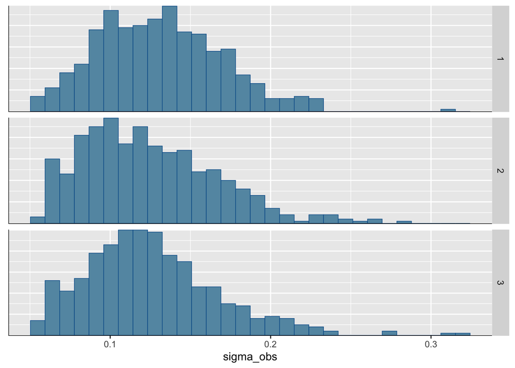

```r
bayesplot::mcmc_hist_by_chain(fit, pars = "sigma_obs")
```

4. If you want to look at the source code (in Stan) for any of the above models, you can do something like this

```r
cat( get_stancode(fit) ) # cat makes this readable
```

```
## data {
##   int<lower=0> N;
##   int<lower=0> n_pos;
##   vector[n_pos] y;
##   int y_int[n_pos];
##   int pos_indx[n_pos+2];
##   int<lower=0> est_drift;
##   int<lower=0> est_nu;
##   int family; // 1 = normal, 2 = binomial, 3 = poisson, 4 = gamma, 5 = lognormal
## }
## parameters {
##   real x0;
##   real mu[est_drift];
##   vector[N-1] pro_dev;
##   real<lower=0> sigma_process;
##   real<lower=0> sigma_obs;
##   real<lower=2> nu[est_nu];
## }
## transformed parameters {
##   vector[N] pred;
##   real temp;
##   pred[1] = x0;
##   temp = 0;
##   if(est_drift==1) {
##     temp = mu[1];
##   }
##   for(i in 2:N) {
##     pred[i] = pred[i-1] + temp + sigma_process*pro_dev[i-1];
##   }
## }
## model {
##   x0 ~ normal(0,10);
##   if(est_drift==1) {
##     mu ~ normal(0,2);
##   }
##   if(est_nu==1) {
##     nu ~ student_t(3,2,2);
##   }
##   sigma_process ~ student_t(3,0,2);
##   sigma_obs ~ student_t(3,0,2);
```

[output cut: 27 more lines]

```
##   if(family==5) {
##     for(i in 1:(n_pos)) {
##       y[i] ~ lognormal(pred[pos_indx[i]], sigma_obs);
##     }
##   }
## }
## generated quantities {
##   vector[n_pos] log_lik;
##   // regresssion example in loo() package
##   if(family==1) for (n in 1:n_pos) log_lik[n] = normal_lpdf(y[n] | pred[pos_indx[n]], sigma_obs);
##   if(family==2) for (n in 1:n_pos) log_lik[n] = bernoulli_lpmf(y_int[n] | inv_logit(pred[pos_indx[n]]));
##   if(family==3) for (n in 1:n_pos) log_lik[n] = poisson_lpmf(y_int[n] | exp(pred[pos_indx[n]]));
##   if(family==4) for (n in 1:n_pos) log_lik[n] = gamma_lpdf(y[n] | sigma_obs, sigma_obs ./ exp(pred[pos_indx[n]]));
##   if(family==5) for (n in 1:n_pos) log_lik[n] = lognormal_lpdf(y[n] | pred[pos_indx[n]], sigma_obs);
## }
```